# Problem Set #4

Hemanth Bharatha Chakravarthy

2/23/2019

# 1 Mad Libs

There were **219** respondents who supported the Democratic candidate.

There were **190** more respondents who favored the Republican candidate than who were Undecided.

There are two gender variables (`gender` and `gender_combined`). There are **10** individuals for whom these variables have different values.

There are **28** respondents listed as “White” under `race_eth` who are not listed as “White” under `file_race_black`.

The first `response` of Rep came **11** minutes (rounded to the nearest minute) before the first response of Dem.

# 2 Distribution of Votes Based on Race

Polling Results in North Carolina 9th Congressional District

|  | Democrat | Republican | Undecided |
| --- | --- | --- | --- |
| White | 33% | 58% | 6% |
| Black | 86% | 3% | 8% |
| Hispanic | 45% | 48% | 7% |
| Asian | 37% | 63% | 0% |
| Other | 49% | 30% | 20% |

Data from The New York Times Upshot

# 3 Education vs Turnout Weights

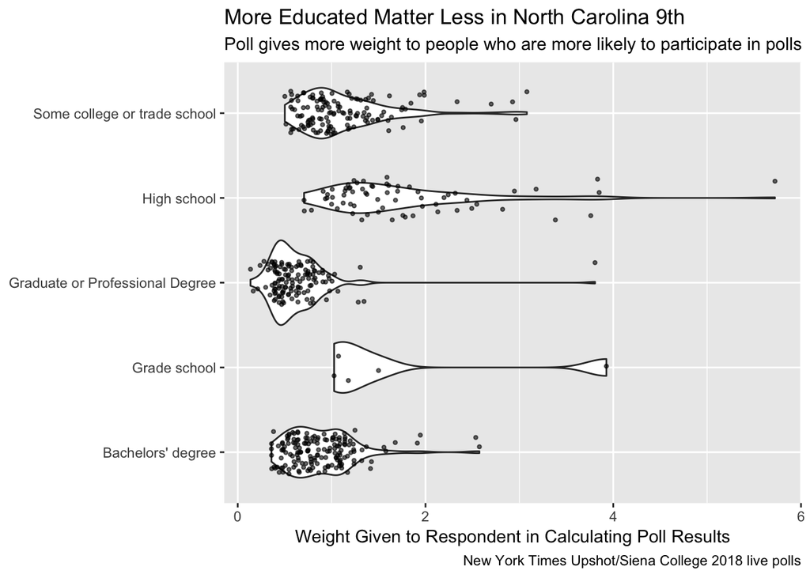

# 4 Race, Gender vs Voting Republican

**This is interesting because it studies whether within the same racial background, gender could swing votes, but we find that it did not do so.**

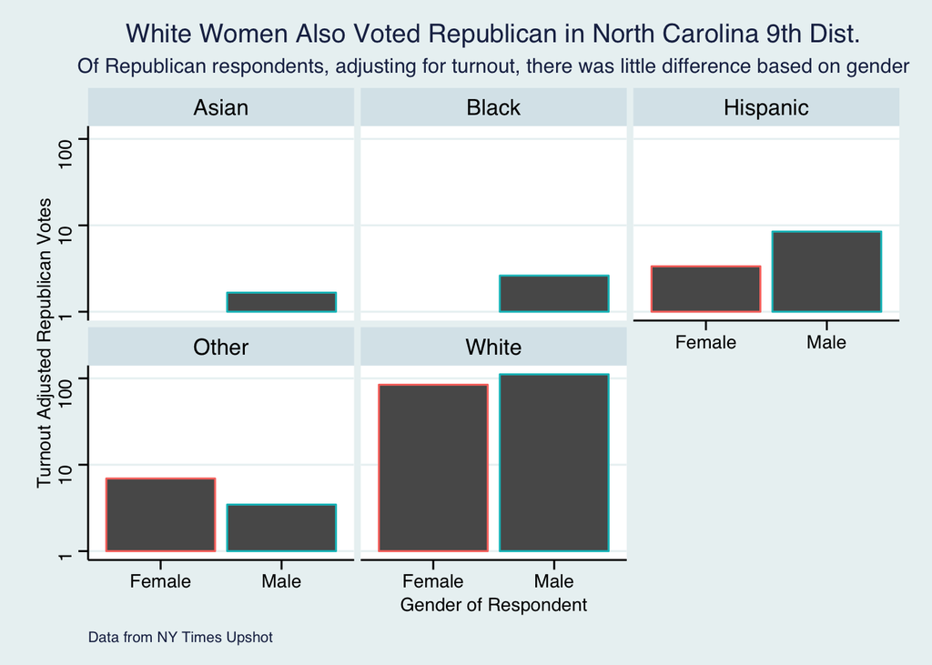